# Figure 2: the skin is a reservoir for antibiotic resistance

Diana Proctor

2023-04-06

last updated: August 04 2023

*draft: submission to Nature, August 2023*

*Manuscript Title*: Fungal Candida auris and bacterial ESKAPE pathogens: Human skin as a reservoir for transmissible microbes and antibiotic resistance in nursing homes

*Authors*: Diana M. Proctor 1, Sarah E Sansom2, Clay Deming1, Sean Conlan1, Ryan A Blaustein1,3, Thomas K. Atkins1,4, NISC Comparative Sequencing Program5, Thelma Dangana2, Christine Fukuda2, Lahari Thotapalli2, Heidi H. Kong6, Michael Y. Lin2, Mary K. Hayden2+ and Julia A. Segre 1+

*Affiliations*:

1Microbial Genomics Section, Translational and Functional Genomics Branch, National Human Genome Research Institute, National Institutes of Health, Bethesda, MD 20892, USA

2 Department of Internal Medicine, Division of Infectious Diseases, Rush University Medical Center, Chicago, IL 60612, USA.

3 Current Address: Department of Nutrition and Food Science, University of Maryland, College Park, MD 20742, USA

4 Current Address: Department of Quantitative and Computational Biology, Princeton University, Princeton, NJ

5 NIH Intramural Sequencing Center, National Human Genome Research Institute, National Institutes of Health, Bethesda, MD 20892, USA.

6 Dermatology Branch, National Institute of Arthritis and Musculoskeletal and Skin Diseases, National Institutes of Health, Bethesda, MD 20892, USA

+Contributed equally

The input for this is the following files, generated using the mags.sh script:

1. mapping_file_2022-08-15_v4.1.csv, the metadata for the shotgun data 2.gtdbtk.arcbaceuk_nature.summary_withabx.csv, which is a blend of the GATK taxonomic output (generated from mags.sh) and the mash/mummer output (generated from mags.sh); I manually concatenated these two taxonomy files
2. ESKAPE_phyloseq_50percent.rds, a phyloseq object describing abundance of species per sample where at least 50% of genome is covered
3. srst2_take3.txt, output of srst2
4. Cauris_MDRO history.csv, the history of antibiotic resistance mechanisms
5. ESKAPE_phyloseq_nocoveragethreshold.rds, the phyloseq object where abundance is defined by total unique reads mapping irrespective of breadth of genome coverage
6. no_MAGs.csv, the file that indicates the subjects for whom we didn’t get MAGs for the species defined in bacteria_of_interest

This script will generate the fo llowing plots:

1. Figure 2
2. correlation between antibiotic resistance gene depth vs. depth of reads mapping to unique species

First let’s load needed R packages.

```
## [1] "1 R packages did not load properly"
```

define the taxa of interest for the figure

```r
#define the taxa of interest
taxa_of_interest = c("Candida auris" ,
      "s__Escherichia coli",
      "s__Enterococcus faecalis",
     "s__Klebsiella pneumoniae" ,
     "s__Acinetobacter baumannii",
      "s__Pseudomonas aeruginosa",
      "s__Proteus mirabilis",
      "s__Providencia stuartii",
     "s__Morganella morganii",
     "s__Staphylococcus aureus")

bacteria_of_interest = c("s__Escherichia coli",
      "s__Enterococcus faecalis",
     "s__Klebsiella pneumoniae" ,
     "s__Acinetobacter baumannii",
      "s__Pseudomonas aeruginosa",
      "s__Proteus mirabilis",
      "s__Providencia stuartii",
     "s__Morganella morganii",
     "s__Staphylococcus aureus")
```

### Let’s read in the data that we will use

```r
#read in the metagenomic data mapping file
map = read.csv("~/Desktop/NATURE/mapping_file_2023-07-23.csv")
mysubjects = unique(map$Unique_ptid)
#now read in the gtdbk classifications, so we can identify which species we find resistance genes in using abricate
gtdbk = read.csv("~/Desktop/NATURE/taxonomy/gtdbtk.arcbaceuk_nature.summary_withabx.csv") %>%
  dplyr::select(., c("user_genome", "msa_percent", "phylum", "genus", "species"))

#add a variable to gtdbk that allows us to merge it with the metagenomic data file
gtdbk$sample = stringr::str_sub(gtdbk$user_genome, 1, 7)
map$sample = map$library_id

#merge all these data frames with each other
df = plyr::join(map, gtdbk) %>%
  subset(., species %in% taxa_of_interest)
```

now let’s determine which samples/subjects were associated with MAGs of each of the select species.

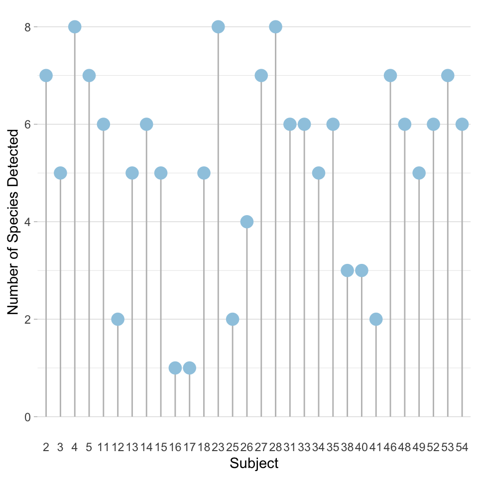

```r
#let's cross tabulate the taxonomy and sample information for the species of interest
crossTab = data.frame(table(df$species,df$Sample)) %>%
    subset(., Var1 %in% taxa_of_interest)

#let's revalue the Malassezias as Malassezia spp.
crossTab$group = plyr::revalue(crossTab$Var1, c("Malassezia arunalokei" ="Malassezia spp.",
     "Malassezia globosa"="Malassezia spp.",
     "Malassezia restricta"="Malassezia spp.",
     "Malassezia furfur"="Malassezia spp.",
     "uncultured Malassezia"="Malassezia spp."))




#clean up the variables by removing s__ from the species names
crossTab$group = stringr::str_remove_all(crossTab$group , "s__")


#regenerate a mapping file from the crosstabulation and subset on the sites of interest
newmap = reshape2::colsplit(crossTab$Var2, ";", c("subject", "site", "survey"))
crossTab = data.frame(crossTab, newmap) %>%
  subset(., !(site %in% c("Site_Bu/To" ,"Site_Ne",    "Site_Ctrl", "Site_Tc")))


#revalue the body sites so that the names are consistent with the other figures
crossTab$Body_Site = plyr::revalue(crossTab$site,
                              c("Site_An" = "Peri-anal",
                                "Site_Ic"="Inguinal crease",
                                "Site_N"="Nares",
                                "Site_Fg"="Fingertips",
                                "Site_Tw"= "Toe web",
                                "Site_Ea"="Ear Canal"))

#we need to correct for the fact that we have spades assemblies AND megahit assemblies for a select number of samples
#replace any count equal to two with a 1
crossTab$Freq = ifelse(crossTab$Freq==2, 1, crossTab$Freq)


#let's now look at how many times we assembled each of the select species out of samples for each subject. We will normalize by the number of samples for each subject.
prevDF = doBy::summary_by(crossTab, Freq~Var1+subject, FUN=c(sum, length))
prevDF$Unique_ptid = as.numeric(stringr::str_sub(prevDF$subject, 9, 10))

#now make a bar of prevalence
burden = prevDF
burden$Prev = ifelse(burden$Freq.sum==0, 0, 1)
burden2 = doBy::summary_by(burden, Prev~subject, FUN=c(sum, length))

ordering = c(1:5, 11:18, 23:38, 40:54)

burden2$Unique_ptid = stringr::str_remove_all(burden2$subject, "Subject_")
burden2$Unique_ptid <- factor(burden2$Unique_ptid, levels = ordering)

# Plot
Fig2Ap1a = ggplot(burden2, aes(x=as.factor(Unique_ptid), y=Prev.sum)) +
  geom_segment( aes(x=Unique_ptid, xend=Unique_ptid, y=0, yend=Prev.sum), color="grey") +
  geom_point( color="#9ECAE1", size=4) +
  theme_light() +
  theme(
    panel.grid.major.x = element_blank(),
    panel.border = element_blank(),
    axis.ticks.x = element_blank()
  ) +
  xlab("Subject") +
  ylab("Number of Species Detected")
Fig2Ap1a
```

```r
#what is the median number of eskape pathogens carried
summary(burden2$Prev.sum)
```

```
##    Min. 1st Qu.  Median    Mean 3rd Qu.    Max.
##   1.000   4.250   6.000   5.167   6.750   8.000
```

### Fig2A

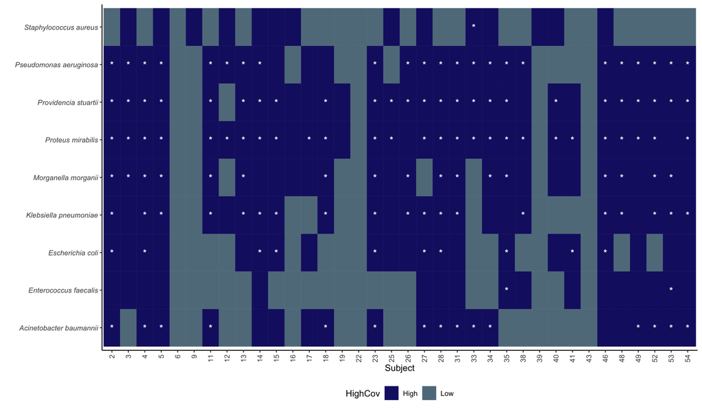

```r
#let's read in the results of the read mapping (unique reads) obtained by bwa-mem
#in order for an abundance value to be present in this table, that species must have had at least 50% of its genome covered in that sample
phy = readRDS("~/Desktop/NATURE/Figure1/ESKAPE_phyloseq_50percent.rds") %>%
  subset_taxa(., species %in% bacteria_of_interest) %>%
  merge_samples(., "Unique_ptid")

#make a data frame of the phyloseq object and clean it up
HighCov = data.frame(t(otu_table(phy)) , tax_table(phy))
HighCovDF = melt(HighCov, colnames(tax_table(phy))) %>%
  dplyr::select(., c("species", "variable", "value"))
colnames(HighCovDF) = c("Var1", "Unique_ptid", "Abundance")
HighCovDF$Unique_ptid = stringr::str_remove_all(HighCovDF$Unique_ptid , "X")
HighCovDF$subject = paste0("Subject_", HighCovDF$Unique_ptid )
HighCovDF$HighCov = ifelse(HighCovDF$Abundance > 0, 1, 0)
HighCovDF = dplyr::select(HighCovDF, "Unique_ptid", "Var1", "HighCov")
HighCovDF$HighCov =  ifelse(HighCovDF$HighCov > 0, "High", "Low")
HighCovDF$Unique_ptid = as.numeric(as.character(HighCovDF$Unique_ptid))



#merge the coverage information with the prevalence information generated in the previous chunk
PA = prevDF
PA$prev =  ifelse(PA$Freq.sum > 0, "Yes", "No")
PA$prev = as.factor(PA$prev)
foo = colsplit(PA$subject, "_",c("Junk", "Unique_ptid"))
PA_DF = data.frame(PA, foo) %>%
  dplyr::select(., c("Unique_ptid", "Var1", "prev"))

#make a data frame for the subjects for which we have coverage but no MAGs
noMAGs = read.csv("~/Desktop/NATURE/ABX_SAMPLES/Manuscript/no_MAGs.csv")[,1:3]

PA_DF = data.frame(rbind(noMAGs, PA_DF))
PA_DF$Unique_ptid = as.numeric(as.character(PA_DF$Unique_ptid))

#merge coverage and presence/absence
FinalDF = dplyr::full_join(PA_DF, HighCovDF)
FinalDF$Var1 = stringr::str_remove_all(FinalDF$Var1, "s__")
FinalDF$MAG = FinalDF$prev
#FinalDF = subset(FinalDF, Var1 !="0")
ordering = c(1:55)
FinalDF$Unique_ptid <- factor(FinalDF$Unique_ptid, levels = ordering)
FinalDF = subset(FinalDF, Var1 != "Candida auris")
#create an annotation data frame for whether or not we recovered a mag for a sample
annotation = subset(FinalDF, MAG=="Yes")
annotation$annotation = "*"
newcolours=c("High"= "midnightblue", "Low"= "lightskyblue4" )

#make figure 2A
Fig2A = ggplot(FinalDF, aes(as.factor(Unique_ptid), Var1))+
  geom_tile(aes(fill=HighCov, color=HighCov)) +
  geom_text(data=annotation, aes( x=as.factor(Unique_ptid), y=Var1, label=annotation),                 ,
           color="white", fontface="bold" ) +
  scale_fill_manual(values=newcolours) +
  scale_color_manual(values=newcolours) +
  theme_classic() + xlab("Subject") +
  theme(axis.text.y = element_text(face = "italic")) + ylab("") +
  theme(legend.position="bottom") +
  theme(axis.text.x = element_text(angle = 90, vjust = 0.5, hjust=1))
Fig2A
```

### Supplementary Figure

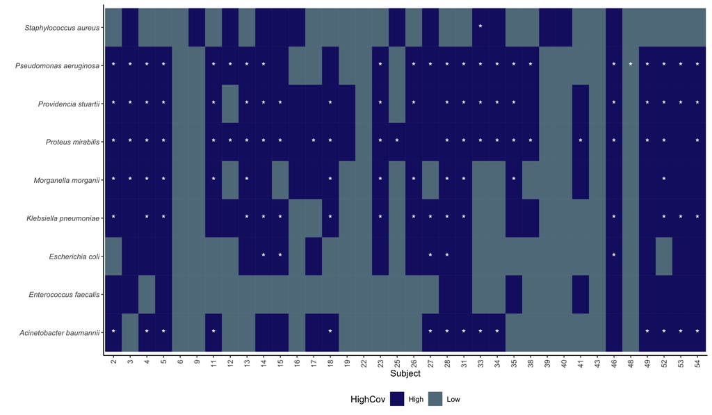

```r
#let's read in the results of the read mapping (unique reads) obtained by bwa-mem
#in order for an abundance value to be present in this table, that species must have had at least 50% of its genome covered in that sample but this time subset on body site and exclude peri-anus
phy = readRDS("~/Desktop/NATURE/Figure1/ESKAPE_phyloseq_50percent.rds") %>%
  subset_taxa(., species %in% taxa_of_interest) %>%
  subset_samples(., site_specific != "An") %>%
  microViz::tax_transform(., trans = "binary", rank = "species") %>%
  merge_samples(., "Unique_ptid", fun=sum)

#make a data frame of the phyloseq object and clean it up
HighCov = data.frame(t(otu_table(phy)) , tax_table(phy))
HighCovDF = melt(HighCov, colnames(tax_table(phy))) %>%
  dplyr::select(., c("species", "variable", "value"))
colnames(HighCovDF) = c("Var1", "Unique_ptid", "Abundance")
HighCovDF$Unique_ptid = stringr::str_remove_all(HighCovDF$Unique_ptid , "X")
HighCovDF$subject = paste0("Subject_", HighCovDF$Unique_ptid )
HighCovDF$HighCov = ifelse(HighCovDF$Abundance > 0, 1, 0)
HighCovDF = dplyr::select(HighCovDF, "Unique_ptid", "Var1", "HighCov")
HighCovDF$HighCov =  ifelse(HighCovDF$HighCov > 0, "High", "Low")
HighCovDF$Unique_ptid = as.numeric(as.character(HighCovDF$Unique_ptid))


### now let's look at the prevalence of MAGs in the absence of the peri-anal samples
#let's cross tabulate the taxonomy and sample information for the species of interest
crossTab = data.frame(table(df$species,df$Sample)) %>%
    subset(., Var1 %in% bacteria_of_interest)


#clean up the variables by removing s__ from the species names
crossTab$group = stringr::str_remove_all(crossTab$Var1 , "s__")


#regenerate a mapping file from the crosstabulation and subset on the sites of interest
newmap = reshape2::colsplit(crossTab$Var2, ";", c("subject", "site", "survey"))
crossTab = data.frame(crossTab, newmap) %>%
  subset(., !(site %in% c("Site_Bu/To" ,"Site_Ne",    "Site_Ctrl", "Site_Tc")))

crossTab = subset(crossTab, site !=  "Site_An")
#revalue the body sites so that the names are consistent with the other figures
crossTab$Body_Site = plyr::revalue(crossTab$site,
                              c("Site_Ic"="Inguinal crease",
                                "Site_N"="Nares",
                                "Site_Fg"="Fingertips",
                                "Site_Tw"= "Toe web",
                                "Site_Ea"="Ear Canal"))

#we need to correct for the fact that we have spades assemblies AND megahit assemblies for a select number of samples
#replace any count equal to two with a 1
crossTab$Freq = ifelse(crossTab$Freq==2, 1, crossTab$Freq)


#let's now look at how many times we assembled each of the select species out of samples for each subject. We will normalize by the number of samples for each subject.
prevDF = doBy::summary_by(crossTab, Freq~Var1+subject, FUN=c(sum, length))
prevDF$Unique_ptid = as.numeric(stringr::str_sub(prevDF$subject, 9, 10))

#merge the coverage information with the prevalence information generated in the previous chunk
PA = prevDF
PA$prev =  ifelse(PA$Freq.sum > 0, "Yes", "No")
PA$prev = as.factor(PA$prev)
foo = colsplit(PA$subject, "_",c("Junk", "Unique_ptid"))
PA_DF = data.frame(PA, foo) %>%
  dplyr::select(., c("Unique_ptid", "Var1", "prev"))

#make a data frame for the subjects for which we have coverage but no MAGs
noMAGs = read.csv("~/Desktop/NATURE/ABX_SAMPLES/Manuscript/no_MAGs.csv")[,1:3]

PA_DF = data.frame(rbind(noMAGs, PA_DF))
PA_DF$Unique_ptid = as.numeric(as.character(PA_DF$Unique_ptid))

#merge coverage and presence/absence
FinalDF = dplyr::full_join(PA_DF, HighCovDF)
FinalDF$Var1 = stringr::str_remove_all(FinalDF$Var1, "s__")
FinalDF$MAG = FinalDF$prev
#FinalDF = subset(FinalDF, Var1 !="0")
ordering = c(1:55)
FinalDF$Unique_ptid <- factor(FinalDF$Unique_ptid, levels = ordering)
FinalDF = subset(FinalDF, Var1 != "Candida auris")
#create an annotation data frame for whether or not we recovered a mag for a sample
annotation = subset(FinalDF, MAG=="Yes")
annotation$annotation = "*"
newcolours=c("High"= "midnightblue", "Low"= "lightskyblue4" )

#make SFig2
SFig2 = ggplot(FinalDF, aes(as.factor(Unique_ptid), Var1))+
  geom_tile(aes(fill=HighCov, color=HighCov)) +
  geom_text(data=annotation, aes( x=as.factor(Unique_ptid), y=Var1, label=annotation),
           color="white", fontface="bold" ) +
  scale_fill_manual(values=newcolours) +
  scale_color_manual(values=newcolours) +
  theme_classic() + xlab("Subject") +
  theme(axis.text.y = element_text(face = "italic")) + ylab("") +
  theme(legend.position="bottom") +
  theme(axis.text.x = element_text(angle = 90, vjust = 0.5, hjust=1))
SFig2
```

```r
ggsave(SFig2, file="~/Desktop/NATURE/ABX_SAMPLES/Manuscript/SupplementaryFigure2.png", height=4, width=12, device="png")
```

### Figure 2B

Detection of 3 carbapenemase producing genes (VIM, KPC, NDM) identified in clinical microbiology findings or surveillance cultures marked as ‘surveillance’ on x-axis. Detection of antibiotic resistance genes by read mapping in shotgun metagenomic data is marked as positive in ‘sequencing’. Each panel represents a unique subject.

okay, now let’s plot the antibiotic resistance data, derived from srst2, a read-based approach.

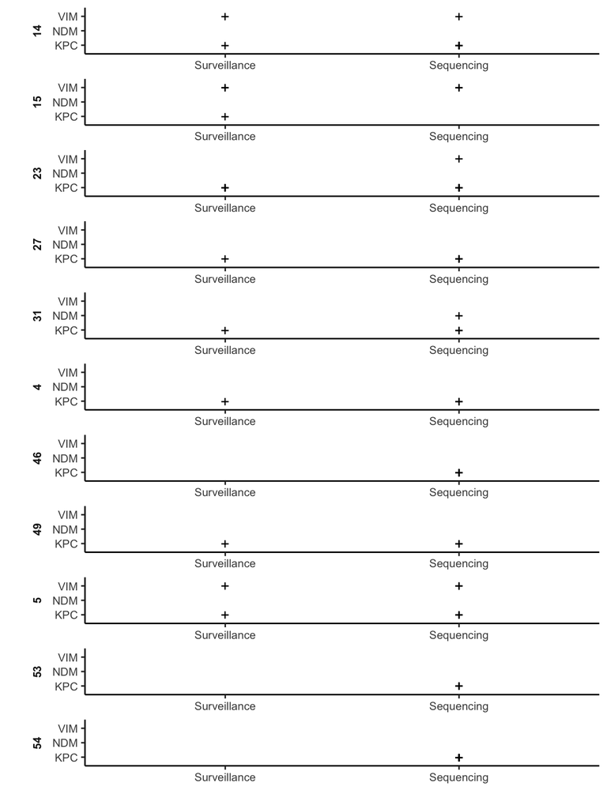

```r
#read srst2 in
srst = read.csv("~/Desktop/NATURE/ABX_SAMPLES/srst2/srst2_take3.csv")
colnames(srst)[1] = "library_id"

#merge srst2 with the sample metadata
srstDF = merge(srst, map)
#write.csv(srstDF,"~/Desktop/NATURE/srstDF_annotated_withabx.csv")

#define the genes we're interested in seeing
Blas = c("CfxA_Bla", "PC1_Bla", "TEM_Bla", "ACI_Bla" ,"CepA_Bla" ,         "OXA_Bla" ,          "PDC_Bla",  "KPC_Bla",
         "SHV-OKP-LEN_Bla" ,"DHA_Bla","VEB_Bla" ,"ADC_Bla", "CTX-M_Bla",  "CKO_Bla" ,
         "AmpC1_Bla" ,  "BIL_Bla" ,"CMY_Bla"   ,  "SRT_Bla"  , "CblA_Bla" ,
         "ACT_Bla" , "VIM_Bla" ,  "NDM_Bla"  )

#define the genes we're interested in seeing
Blas2 = c( "KPC_Bla", "VIM_Bla" ,  "NDM_Bla"  )

#subset the srst2 results on just the carbepenamse genes since we have surveillance data for them
carbs = subset(srstDF, gene %in% Blas2)
carbs$gene = stringr::str_sub(carbs$gene, 1, 3)
carbs = subset(carbs, gene %in% c("KPC", "NDM", "VIM"))
carbs = dplyr::select(carbs, c("Unique_ptid", "Survey_Period", "site_specific", "gene"))
#create a variable in the sequencing results to denote positivity and identification type
carbs$is.positive = "+"
carbs$Type = "Sequencing"
SeqPositiveSubjects = unique(carbs$Unique_ptid)


#read in the surveillance/clinical microbiology findings
PCRpositives = read.csv("~/Desktop/NATURE/new_clinical_data_2023/Cauris_MDRO history.csv")
#subset on the findings with a mechanism of action and annotate
PCRpositives = dplyr::select(PCRpositives, c("Unique_ptid","Mechanism", "Sample_type"))%>%
  subset(., Mechanism !="Unknown")
colnames(PCRpositives)[3] = "site_specific"
PCRpositives$Survey_Period = ""
colnames(PCRpositives)[2] = "gene"
PCRpositives$is.positive = "+"
PCRpositives$Type = "Surveillance"

#make a data frame combining sequencing results and the surveillance findings and subset on the patients we analyzed by shotgun
mydf = data.frame(rbind(PCRpositives, carbs)) %>%
  subset(., Unique_ptid %in% SeqPositiveSubjects)

#let's add values for Surveillance for subjects for whom we get sequencing results
s46 = c(46, "KPC", "", "", "", "Surveillance")
s53 = c(53, "KPC", "", "", "", "Surveillance")
s54 = c(54, "KPC", "", "", "", "Surveillance")

newdf = data.frame(rbind(mydf, s46, s53, s54))

ordering = c("Surveillance", "Sequencing"  )
newdf$Type <- factor(newdf$Type, levels = ordering)
newdf = subset(newdf, gene != "NDM-1")
#write.csv(newdf, file="~/Desktop/NATURE/ABX_SAMPLES/surveillance_sequencing.csv")
#make a plot for antibiotic genes
Fig2B = ggplot(newdf, aes(Type, gene, label=is.positive)) + geom_text() +
  facet_wrap(~Unique_ptid, scales="free_x", strip.position="left", ncol=1) +
   ylab("")+
   xlab("") + theme_classic() +
  theme(strip.background = element_blank(),
    strip.placement = "outside",
    strip.text.y = element_text(size=8, face="bold", angle=0),
     strip.text.x = element_text(size=8, face="bold", angle=0)) +
  theme(axis.text = element_text(size = 8))

Fig2B
```

```r
mydf = data.frame(rbind(PCRpositives, carbs)) %>%
  subset(., Unique_ptid %in% mysubjects)


#let's add values for Surveillance for subjects for whom we get sequencing results
s46 = c(46, "KPC", "", "", "", "Surveillance")
s53 = c(53, "KPC", "", "", "", "Surveillance")
s54 = c(54, "KPC", "", "", "", "Surveillance")

newdf = data.frame(rbind(mydf, s46, s53, s54))

ordering = c("Surveillance", "Sequencing"  )
newdf$Type <- factor(newdf$Type, levels = ordering)
newdf = subset(newdf, gene != "NDM-1")
#write.csv(newdf, file="~/Desktop/NATURE/ABX_SAMPLES/surveillance_sequencing.csv")
#make a plot for antibiotic genes
Fig2B_All = ggplot(newdf, aes(Type, gene, label=is.positive)) + geom_text() +
  facet_wrap(~Unique_ptid, scales="free_x", strip.position="left", ncol=2) +
   ylab("")+
   xlab("") + theme_classic() +
  theme(strip.background = element_blank(),
    strip.placement = "outside",
    strip.text.y = element_text(size=8, face="bold", angle=0),
     strip.text.x = element_text(size=8, face="bold", angle=0)) +
  theme(axis.text = element_text(size = 8))
```

### SFig3: how persistent are these genes over time

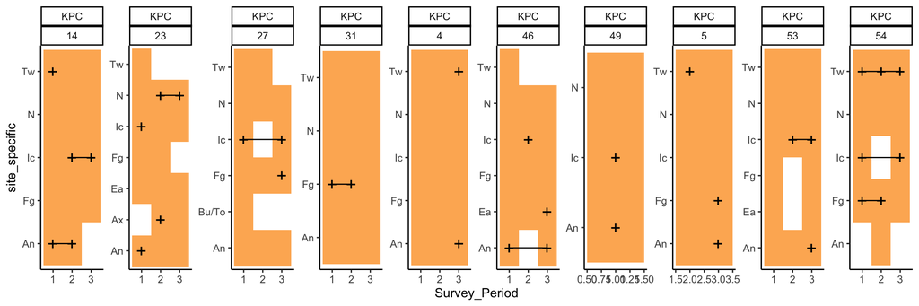

```r
mymap = subset(map, Unique_ptid %in% carbs$Unique_ptid)
mymap = subset(mymap, Unique_ptid !=15)
newdf = subset(newdf, Type=="Sequencing")

#let's subset on KPC and plot
kpc = subset(newdf, gene=="KPC")
kpc$Survey_Period = as.numeric(as.character(kpc$Survey_Period))

#subset on the people who were sequencing positive
kpc = subset(kpc, Unique_ptid %in% carbs$Unique_ptid)
kpc = subset(kpc, Unique_ptid != 15)
SFig3 = ggplot(kpc) + theme_classic2() +
  geom_tile(data=mymap, aes(Survey_Period, site_specific), alpha=1, fill="#FDB462") +
  geom_line(aes(Survey_Period, site_specific, group=site_specific)) +
  geom_text(aes(Survey_Period, site_specific, label=is.positive), size=6)  +
  facet_wrap(gene~Unique_ptid, scales="free", ncol=11)
SFig3
```

```r
ggsave(SFig3, file="~/Desktop/NATURE/ABX_SAMPLES/Manuscript/SupplementaryFigure3.png", device="png",
       height=4, width=12)
```

note that we also see the persistence of the VIM genes in the nares in subject 15

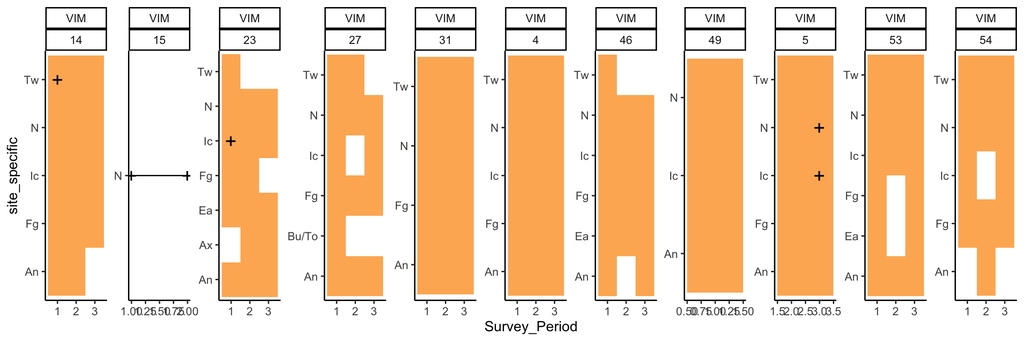

```r
#let's subset on vim and plot
vim = subset(newdf, gene=="VIM")
vim$Survey_Period = as.numeric(as.character(vim$Survey_Period))

#subset on the people who were sequencing positive
vim = subset(vim, Unique_ptid %in% carbs$Unique_ptid)
ggplot(vim) + theme_classic2() +
  geom_tile(data=mymap, aes(Survey_Period, site_specific), alpha=1, fill="#FDB462") +
  geom_line(aes(Survey_Period, site_specific, group=site_specific)) +
  geom_text(aes(Survey_Period, site_specific, label=is.positive), size=6)  +
  facet_wrap(gene~Unique_ptid, scales="free", ncol=11)
```

### let’s look at the correlation of the carbepenamse genes with the various reads.

[figure not shown]

```r
#select just the columns of interest in the srst data
srstDF = dplyr::select(srstDF, c("library_id",  "gene",  "allele", "coverage",  "depth",       "diffs",
                                 "uncertainty", "divergence",
                                 "length", "maxMAF", "clusterid", "seqid"))

#we will read in the phyloseq object without a breadth of coverage restriction
myphy = readRDS("~/Desktop/NATURE/Figure1/ESKAPE_phyloseq_nocoveragethreshold.rds")
myreads = data.frame(otu_table(myphy), tax_table(myphy)) %>%
  reshape::melt(., colnames(tax_table(myphy)))
myreads$library_id = myreads$variable

#merge the taxon abundance with the srst results
newDF = plyr::join(srstDF, myreads)
newDF = subset(newDF, species %in% taxa_of_interest) %>%
  subset(., gene %in% c("VIM_Bla" ,  "KPC_Bla", "OXA_Bla" ))

#specify a model
my.formula<- y ~ x

# plot the correlations
p = ggplot(newDF, aes( value, depth)) +
  geom_point() + scale_x_log10() +
  scale_y_log10() +
  facet_wrap(gene~species, ncol=5) +
  geom_smooth(method = "lm")+
  stat_poly_eq(formula = my.formula, aes(label = paste(..eq.label.., ..rr.label.., sep = "~~~")), parse = TRUE)  +
  geom_point()
p
```

```r
#are any of the correlation coefficients greater than 0.2 significant
kpc_kp = subset(newDF, species=="s__Klebsiella pneumoniae" & gene=="KPC_Bla")
cor.test(kpc_kp$depth, kpc_kp$value, alternative="greater",method="pearson")
```

```
##
##  Pearson's product-moment correlation
##
## data:  kpc_kp$depth and kpc_kp$value
## t = 1.9025, df = 34, p-value = 0.0328
## alternative hypothesis: true correlation is greater than 0
## 95 percent confidence interval:
##  0.03440478 1.00000000
## sample estimates:
##       cor
## 0.3101855
```

```r
#are any of the correlation coefficients greater than 0.2 significant
oxa_ps = subset(newDF, species=="s__Providencia stuartii" & gene=="OXA_Bla")
cor.test(oxa_ps$depth, oxa_ps$value, alternative="greater",method="pearson")
```

```
##
##  Pearson's product-moment correlation
##
## data:  oxa_ps$depth and oxa_ps$value
## t = 6.3509, df = 148, p-value = 1.242e-09
## alternative hypothesis: true correlation is greater than 0
## 95 percent confidence interval:
##  0.3497642 1.0000000
## sample estimates:
##       cor
## 0.4627777
```

### Let’s generate figure 2

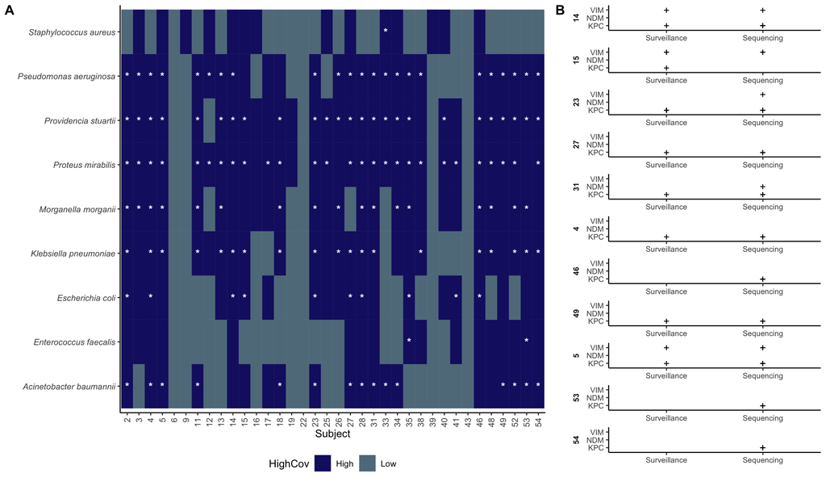

```r
Left = plot_grid(Fig2A, rel_heights = 0.5, labels="A")
Right = plot_grid(Fig2B, rel_heights = 1, labels="B")
Fig2 = plot_grid(Left, Right, ncol=2, rel_widths =c(1, 0.5))
Fig2
```

```r
ggsave(Fig2, file="~/Desktop/NATURE/ABX_SAMPLES/Manuscript/Figure2.pdf", device="pdf", height = 9, width = 7)
```